GeoStat Lab · M10 · Previsione e progetto statistico

M10_N03 · Futura

# Stimare il modello sui livelli, non sulle differenze già calcolate

5 blocchi R eseguiti1 grafico0 errori · 0 avvisiOffline · MathML

Codice, output e figure dello stesso svolgimento. Ogni notebook riparte dai dati locali ed è autonomo rispetto agli altri.

# La domanda

Come si applica correttamente una specifica SARIMA?

## Obiettivi

- Dichiarare ordini e periodo stagionale.
- Stimare sui livelli lasciando le differenze alla funzione.
- Controllare convergenza e struttura dei coefficienti.

**Prima di iniziare.** Sono richiesti vettori, tabelle e funzioni R di base. I blocchi vanno eseguiti in ordine. Il notebook è autonomo rispetto agli altri.

**Dati e unità.** CO₂ storica: 204 mesi da gennaio 1985 a dicembre 2001, concentrazione in ppm. Le medie derivano dalle osservazioni settimanali attribuite al mese della data, secondo la convenzione del corso. Sono dati storici, distinti da una serie mensile ufficiale e da una misura attuale. Il protocollo usa 168 mesi per l’adattamento (1985–1998) e 36 per il test (1999–2001).

## Preparazione

Aprire il progetto autonomo di Futura o quello generale del corso. I calcoli usano R base e stats. Gli output del notebook vanno in `Risultati/M10_N03/`; i CSV originali restano invariati.

Codice R · preparazione

```r
# Trova la cartella M10 dal progetto autonomo o dal progetto generale.
.gs_cerca <- normalizePath(getwd(),winslash="/",mustWork=TRUE)
repeat {
  .gs_candidati <- c(.gs_cerca,
    file.path(.gs_cerca,"M10_Futura"),
    file.path(.gs_cerca,"03_Notebook_svolti","M10_Futura"),
    file.path(.gs_cerca,"M10","03_Notebook_svolti","M10_Futura"))
  .gs_ok <- file.exists(file.path(.gs_candidati,"M10_N01.Rmd")) &
    file.exists(file.path(.gs_candidati,"R","funzioni_notebook.R"))
  if(any(.gs_ok)) { .gs_modulo <- .gs_candidati[which(.gs_ok)[1L]]; break }
  .gs_padre <- dirname(.gs_cerca)
  if(.gs_padre==.gs_cerca) stop("Aprire il progetto M10_Futura o quello generale dei notebook.")
  .gs_cerca <- .gs_padre
}
source(file.path(.gs_modulo,"R","funzioni_notebook.R"),local=TRUE)
.gs_funzioni <- .gs_prepara_notebook(.gs_modulo,"M10_N03")
carica_dati <- .gs_funzioni$carica_dati
percorso_risultati <- .gs_funzioni$percorso_risultati
options(width=88,digits=6)
if(requireNamespace("knitr",quietly=TRUE)) {
  knitr::opts_chunk$set(echo=TRUE,error=FALSE,warning=TRUE,message=TRUE,
    fig.width=8,fig.height=5,dpi=150,fig.align="center")
}
set.seed(10003)
```

## 1. La specifica entra nella funzione

Nel modello SARIMA$(0,1,1)(0,1,1)_{12}$, le differenze ordinaria e stagionale sono interne alla stima. In R i coefficienti MA usano la convenzione con il segno più.

Codice R · passo_01

```r
c2 <- prepara_co2(carica_dati("co2_1985_2001.csv"))
train <- c2$train; test <- c2$test; h <- c2$h
 fit <- stats::arima(train,order=c(0,1,1),
   seasonal=list(order=c(0,1,1),period=12),
   include.mean=FALSE,method="ML")
 fit
 stopifnot(is.null(fit$code) || fit$code==0L)
```

Output eseguito

```
Call:
stats::arima(x = train, order = c(0, 1, 1), seasonal = list(order = c(0, 1,
    1), period = 12), include.mean = FALSE, method = "ML")

Coefficients:
         ma1    sma1
      -0.329  -0.890
s.e.   0.078   0.115

sigma^2 estimated as 0.0896:  log likelihood = -42.22,  aic = 90.44
```

**Lettura del risultato.** La stima riceve i 168 livelli. La chiamata dichiara due differenze e due termini MA, senza drift. Il numero di coefficienti non misura da solo l’adeguatezza del modello.

## 2. Coefficienti e precisione numerica

Il modello soddisfa $(1-B)(1-B^{12})y_t=(1+\theta B)(1+\Theta B^{12})\varepsilon_t$. Gli errori standard sono quelli dell’approssimazione della stima.

Codice R · passo_02

```r
data.frame(termine=names(coef(fit)),stima=as.numeric(coef(fit)),
  errore_standard=sqrt(diag(fit$var.coef)))
data.frame(varianza_innovazioni=fit$sigma2,logLik=as.numeric(logLik(fit)),
           AIC=AIC(fit),codice_convergenza=fit$code)
stopifnot(length(coef(fit))==2L,all(is.finite(fit$var.coef)))
```

Output eseguito

```
     termine     stima errore_standard
ma1      ma1 -0.328848       0.0784764
sma1    sma1 -0.889699       0.1146449
  varianza_innovazioni   logLik     AIC codice_convergenza
1            0.0896181 -42.2189 90.4379                  0
```

**Lettura del risultato.** La convergenza è un requisito di calcolo, non una garanzia scientifica. AIC riguarda l’adattamento penalizzato e va distinto dalla prestazione futura.

## 3. La differenza esplicita serve a capire

Costruiamo la trasformazione separatamente per controllarne l’indice temporale. Questo oggetto serve alla diagnosi, mentre il modello precedente resta stimato sui livelli.

Codice R · passo_03

```r
z <- diff(diff(train,lag=12),differences=1)
data.frame(livelli=length(train),dopo_differenza_12=length(diff(train,lag=12)),
           doppia_differenza=length(z))
stile_grafico()
plot(z,type="l",col=palette_geo[1],xlab="Anno",ylab="Differenza (ppm)",
     main="Trasformazione diagnostica: (1-B)(1-B^12)")
abline(h=0,lty=2)
```

Output eseguito

```
  livelli dopo_differenza_12 doppia_differenza
1     168                156               155
```

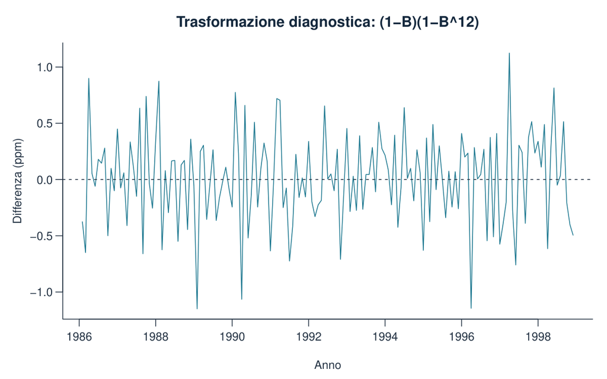

Figura 1 · Output del blocco `passo_03`. PDF vettoriale.

**Lettura del risultato.** La trasformazione esplicita conserva 155 valori. Passarla di nuovo a una chiamata con d=1 e D=1 introdurrebbe altre differenze.

## Variante svolta

**Una specifica alternativa dichiarata.** Stimare un modello stagionale con il solo termine MA stagionale. Il confronto è esplorativo all’interno del train.

Codice R · variante

```r
alternativo <- arima(train,order=c(0,1,0),
  seasonal=list(order=c(0,1,1),period=12),include.mean=FALSE,method="ML")
stopifnot(is.null(alternativo$code)||alternativo$code==0L)
data.frame(modello=c("MA1 e MA stagionale","Solo MA stagionale"),
           AIC=c(AIC(fit),AIC(alternativo)))
```

Output eseguito

```
              modello      AIC
1 MA1 e MA stagionale  90.4379
2  Solo MA stagionale 102.5735
```

Le due specifiche condividono differenze, campione e metodo ML. Il confronto AIC è interpretabile in questo contesto, ma il modello scelto richiede ancora diagnostica e validazione.

## Errore da riconoscere

Applicare diff due volte ai dati e poi dichiarare ancora d=1 e D=1 in arima.

## Risposta alla domanda

La specifica SARIMA va applicata ai livelli quando arima gestisce le differenze. Ordini, metodo di stima, componenti deterministiche e convergenza fanno parte del risultato riproducibile.

## Riferimento nel corso

Questo svolgimento sviluppa il laboratorio `M10_N03` di [GeoStat Lab M10](https://marzione00.github.io/Lab_Geo/#indice). Il [codice originale del laboratorio](https://github.com/marzione00/Lab_Geo/blob/649f7cc577b96bd1044d81e78a2f530813e4f96b/materiali/laboratori/M10/M10_N03.R) è conservato anche in `R/Originali_corso`. Gli ampliamenti e le varianti sono identificati nella mappa allegata.

Documentazione dei metodi: [R stats, arima](https://stat.ethz.ch/R-manual/R-devel/library/stats/html/arima.html), [predict.Arima](https://stat.ethz.ch/R-manual/R-devel/library/stats/html/predict.arima.html), [Box.test](https://stat.ethz.ch/R-manual/R-devel/library/stats/html/box.test.html) e [p.adjust](https://stat.ethz.ch/R-manual/R-devel/library/stats/html/p.adjust.html).